# Orthogonal House Price Dataset — Analysis Report

### Author: Oamen Dominion | Student No: 2021332339

This notebook analyses an experimentally designed orthogonal house price dataset generated in R. The dataset is fully balanced across all factor combinations, guaranteeing zero correlation among predictors. We verify orthogonality, train a linear regression model, and evaluate its ability to recover the true population coefficients.

```python
import numpy as np
import pandas as pd

import matplotlib.pyplot as plt
%matplotlib inline

from sklearn.preprocessing import LabelEncoder
```

## 1. Data Loading & Preprocessing

Load the dataset and encode categorical variables numerically. `size_cat` and `dist_cat` are ordinal-encoded to preserve natural ordering. `renovated` and `location` are already sum-coded (-1/+1) from R.

```python
data = pd.read_csv('hdata_experimental.csv')
data.head(5)
```

|  | size_cat | dist_cat | renovated | location | size | dist_km | price |
| --- | --- | --- | --- | --- | --- | --- | --- |
| 0 | Small | Near | -1 | -1 | -1.000000 | 1.836730 | 920186.634965 |
| 1 | Small | Near | -1 | -1 | -0.977528 | -1.640352 | 538365.270327 |
| 2 | Small | Near | -1 | -1 | -0.955056 | -1.130935 | 753008.536659 |
| 3 | Small | Near | -1 | -1 | -0.932584 | -0.841998 | 687319.989665 |
| 4 | Small | Near | -1 | -1 | -0.910112 | -1.393441 | 792542.545263 |

```python
data.dtypes
```

```
size_cat      object
dist_cat      object
renovated      int64
location       int64
size         float64
dist_km      float64
price        float64
dtype: object
```

```python
data.shape
data.describe()
```

|  | renovated | location | size | dist_km | price |
| --- | --- | --- | --- | --- | --- |
| count | 2160.000000 | 2160.000000 | 2.160000e+03 | 2.160000e+03 | 2.160000e+03 |
| mean | 0.000000 | 0.000000 | -2.631640e-17 | -1.887379e-16 | 8.253176e+05 |
| std | 1.000232 | 1.000232 | 5.839365e-01 | 9.417837e-01 | 2.124097e+05 |
| min | -1.000000 | -1.000000 | -1.000000e+00 | -1.678951e+00 | 1.478764e+05 |
| 25% | -1.000000 | -1.000000 | -5.056180e-01 | -6.399082e-01 | 6.753454e+05 |
| 50% | 0.000000 | 0.000000 | 0.000000e+00 | -2.057392e-02 | 8.233603e+05 |
| 75% | 1.000000 | 1.000000 | 5.056180e-01 | 5.279830e-01 | 9.647018e+05 |
| max | 1.000000 | 1.000000 | 1.000000e+00 | 2.520239e+00 | 1.597843e+06 |

```python
le = LabelEncoder()
data['size_cat'] = le.fit_transform(data['size_cat'])
data['dist_cat']  = le.fit_transform(data['dist_cat'])

print(data.dtypes)
print(data.head())
```

```
size_cat       int32
dist_cat       int32
renovated      int64
location       int64
size         float64
dist_km      float64
price        float64
dtype: object
   size_cat  dist_cat  renovated  location      size   dist_km          price
0         2         1         -1        -1 -1.000000  1.836730  920186.634965
1         2         1         -1        -1 -0.977528 -1.640352  538365.270327
2         2         1         -1        -1 -0.955056 -1.130935  753008.536659
3         2         1         -1        -1 -0.932584 -0.841998  687319.989665
4         2         1         -1        -1 -0.910112 -1.393441  792542.545263
```

## 2. Orthogonality Verification

A key property of this dataset is that all predictors are mutually uncorrelated. We verify this by computing the predictor-only correlation matrix. All off-diagonal values should be exactly 0, confirming orthogonality.

```
           size_cat  dist_cat  renovated  location  size  dist_km
size_cat        1.0      -0.0        0.0      -0.0   0.0      0.0
dist_cat       -0.0       1.0       -0.0      -0.0   0.0     -0.0
renovated       0.0      -0.0        1.0       0.0   0.0     -0.0
location       -0.0      -0.0        0.0       1.0  -0.0      0.0
size            0.0       0.0        0.0      -0.0   1.0     -0.0
dist_km         0.0      -0.0       -0.0       0.0  -0.0      1.0
```

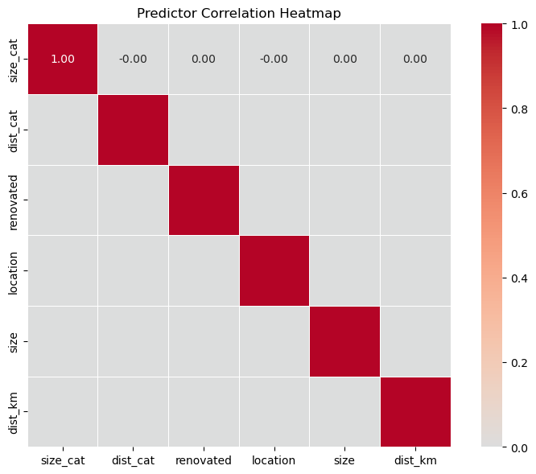

```python
# Predictor-only correlation matrix (exclude price)
predictors = ['size_cat', 'dist_cat', 'renovated', 'location', 'size', 'dist_km']
corr_matrix = data[predictors].corr()
print(round(corr_matrix, 4))

# Heatmap
plt.figure(figsize=(8, 6))
sns.heatmap(corr_matrix,
            annot      = True,
            fmt        = ".2f",
            cmap       = "coolwarm",
            center     = 0,
            square     = True,
            linewidths = 0.5)
plt.title("Predictor Correlation Heatmap")
plt.tight_layout()
plt.show()
```

## 3. Train/Test Split

A standard random split would destroy the balanced factorial structure and break orthogonality. Instead we split **within each cell** of the design — every unique combination of factors contributes exactly 80% of its rows to training and 20% to test, preserving balance in both sets.

```python
from sklearn.model_selection import GroupShuffleSplit

# Create a cell identifier — every unique combination of the 4 factors
data['cell'] = (data['size_cat'].astype(str) + '_' +
                data['dist_cat'].astype(str) + '_' +
                data['renovated'].astype(str) + '_' +
                data['location'].astype(str))

# Split within each cell (80/20) preserving balance
train_idx = []
test_idx  = []

for cell, group in data.groupby('cell'):
    n         = len(group)
    n_train   = int(n * 0.8)
    idx       = group.index.tolist()
    train_idx.extend(idx[:n_train])
    test_idx.extend(idx[n_train:])

train = data.loc[train_idx].reset_index(drop=True)
test  = data.loc[test_idx].reset_index(drop=True)

# Verify balance
print("Train size:", len(train))
print("Test size: ", len(test))
print("\nTrain cell counts:\n", train.groupby('cell').size().unique())
print("Test cell counts:\n",  test.groupby('cell').size().unique())
```

```
Train size: 1728
Test size:  432

Train cell counts:
 [72]
Test cell counts:
 [18]
```

## 4. Model Training

We fit an Ordinary Least Squares linear regression model including the `size:location` interaction term, mirroring the true data generating process used in R. Because predictors are orthogonal, each coefficient is estimated independently without interference from the others.

```python
# Recode to 0/1 for sklearn compatibility
train['renovated_01'] = (train['renovated'] == 1).astype(int)
train['location_01']  = (train['location']  == 1).astype(int)
test['renovated_01']  = (test['renovated']  == 1).astype(int)
test['location_01']   = (test['location']   == 1).astype(int)

# Recreate interaction with 0/1 location
train['size_x_location'] = train['size'] * train['location_01']
test['size_x_location']  = test['size']  * test['location_01']

features = ['renovated_01', 'location_01', 'size', 'dist_km', 'size_x_location']

X_train = train[features]
X_test  = test[features]

model = LinearRegression()
model.fit(X_train, y_train)

y_pred_train = model.predict(X_train)
y_pred_test  = model.predict(X_test)

r2_train   = r2_score(y_train, y_pred_train)
r2_test    = r2_score(y_test,  y_pred_test)
rmse_train = np.sqrt(mean_squared_error(y_train, y_pred_train))
rmse_test  = np.sqrt(mean_squared_error(y_test,  y_pred_test))

print("=" * 40)
print("        MODEL PERFORMANCE SUMMARY")
print("=" * 40)
print(f"Train R²   : {r2_train:.4f}")
print(f"Test  R²   : {r2_test:.4f}")
print(f"Train RMSE : {rmse_train:,.2f}")
print(f"Test  RMSE : {rmse_test:,.2f}")
print("=" * 40)

coef_df = pd.DataFrame({
    'Feature'    : features,
    'Coefficient': model.coef_
}).sort_values('Coefficient', ascending=False)

print("\nCoefficients:")
print(coef_df.to_string(index=False))
print(f"\nIntercept: {model.intercept_:,.2f}")
```

```
========================================
        MODEL PERFORMANCE SUMMARY
========================================
Train R²   : 0.3432
Test  R²   : 0.3532
Train RMSE : 170,326.88
Test  RMSE : 166,115.67
========================================

Coefficients:
        Feature   Coefficient
    location_01 201859.201638
   renovated_01 145470.291812
size_x_location  17621.454946
        dist_km  -4255.452528
           size -12697.969430

Intercept: 651,577.42
```

## 5. Test Set Evaluation

We evaluate the trained model on the held-out 20% test set. Given the orthogonal balanced design, we expect Train R² and Test R² to be very close — a large gap would indicate overfitting.

```
========================================
        TEST SET PERFORMANCE
========================================
Test R²   : 0.3532
Test RMSE : 166,115.67
Test MAE  : 130,765.16
========================================
```

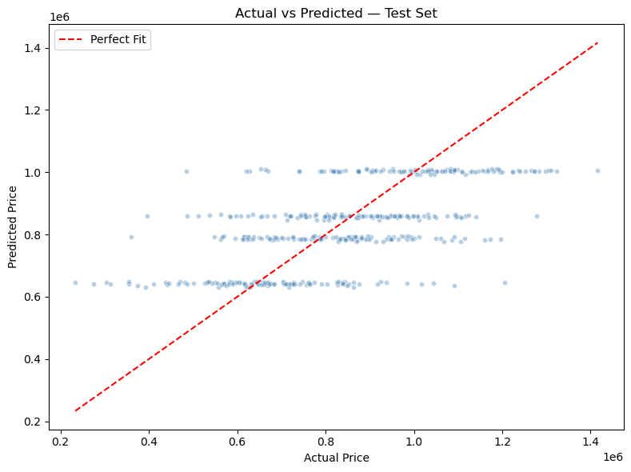

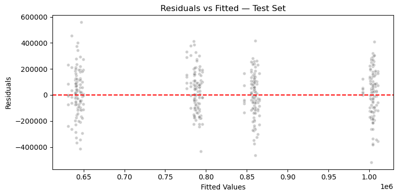

```python
# Evaluate on test data
y_pred_test = model.predict(X_test)

# Performance metrics
r2_test   = r2_score(y_test, y_pred_test)
rmse_test = np.sqrt(mean_squared_error(y_test, y_pred_test))
mae_test  = np.mean(np.abs(y_test - y_pred_test))

print("=" * 40)
print("        TEST SET PERFORMANCE")
print("=" * 40)
print(f"Test R²   : {r2_test:.4f}")
print(f"Test RMSE : {rmse_test:,.2f}")
print(f"Test MAE  : {mae_test:,.2f}")
print("=" * 40)

# Actual vs Predicted plot
plt.figure(figsize=(8, 6))
plt.scatter(y_test, y_pred_test, alpha=0.4, color='steelblue', edgecolors='white', s=20)
plt.plot([y_test.min(), y_test.max()],
         [y_test.min(), y_test.max()],
         color='red', linestyle='--', linewidth=1.5, label='Perfect Fit')
plt.xlabel('Actual Price')
plt.ylabel('Predicted Price')
plt.title('Actual vs Predicted — Test Set')
plt.legend()
plt.tight_layout()
plt.show()

# Residuals on test set
residuals_test = y_test - y_pred_test

plt.figure(figsize=(8, 4))
plt.scatter(y_pred_test, residuals_test, alpha=0.4, color='grey', edgecolors='white', s=20)
plt.axhline(0, color='red', linestyle='--', linewidth=1.5)
plt.xlabel('Fitted Values')
plt.ylabel('Residuals')
plt.title('Residuals vs Fitted — Test Set')
plt.tight_layout()
plt.show()
```

## 6. Summary Visualisation

A five-panel summary bringing together model diagnostics, coefficient recovery, and performance metrics. The **True vs Estimated Coefficients** panel directly compares recovered betas against the known ground truth from R.

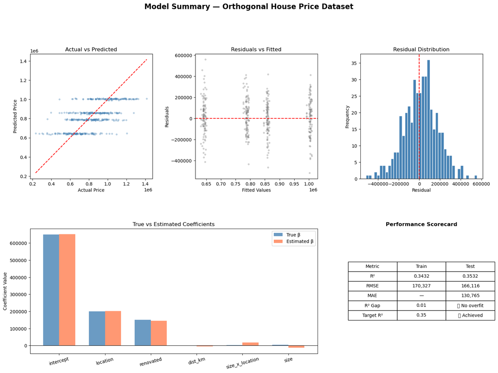

```python
import matplotlib.gridspec as gridspec


# ---- Data Prep ----
true_betas = {
    'intercept'      : 650000,
    'location'       : 200000,
    'renovated'      : 150000,
    'dist_km'        : -2000,
    'size_x_location': 2000,
    'size'           : 5000
}

estimated = {
    'intercept'      : 651577.42,
    'location'       : 201859.20,
    'renovated'      : 145470.29,
    'dist_km'        : -4255.45,
    'size_x_location': 17621.45,
    'size'           : -12697.97
}

labels        = list(true_betas.keys())
true_vals     = list(true_betas.values())
est_vals      = list(estimated.values())
residuals_test = y_test - y_pred_test

# ---- Layout ----
fig = plt.figure(figsize=(18, 12))
fig.suptitle('Model Summary — Orthogonal House Price Dataset',
             fontsize=16, fontweight='bold', y=1.01)
gs = gridspec.GridSpec(2, 3, figure=fig, hspace=0.4, wspace=0.35)

# ---- 1. Actual vs Predicted ----
ax1 = fig.add_subplot(gs[0, 0])
ax1.scatter(y_test, y_pred_test, alpha=0.3, color='steelblue', s=10)
ax1.plot([y_test.min(), y_test.max()],
         [y_test.min(), y_test.max()],
         color='red', linestyle='--', linewidth=1.5)
ax1.set_xlabel('Actual Price')
ax1.set_ylabel('Predicted Price')
ax1.set_title('Actual vs Predicted')

# ---- 2. Residuals vs Fitted ----
ax2 = fig.add_subplot(gs[0, 1])
ax2.scatter(y_pred_test, residuals_test, alpha=0.3, color='grey', s=10)
ax2.axhline(0, color='red', linestyle='--', linewidth=1.5)
ax2.set_xlabel('Fitted Values')
ax2.set_ylabel('Residuals')
ax2.set_title('Residuals vs Fitted')

# ---- 3. Residual Distribution ----
ax3 = fig.add_subplot(gs[0, 2])
ax3.hist(residuals_test, bins=40, color='steelblue', edgecolor='white')
ax3.axvline(0, color='red', linestyle='--', linewidth=1.5)
ax3.set_xlabel('Residual')
ax3.set_ylabel('Frequency')
ax3.set_title('Residual Distribution')

# ---- 4. True vs Estimated Coefficients ----
ax4 = fig.add_subplot(gs[1, 0:2])
x     = np.arange(len(labels))
width = 0.35
ax4.bar(x - width/2, true_vals, width, label='True β',      color='steelblue', alpha=0.8)
ax4.bar(x + width/2, est_vals,  width, label='Estimated β', color='coral',     alpha=0.8)
ax4.set_xticks(x)
ax4.set_xticklabels(labels, rotation=15)
ax4.axhline(0, color='black', linewidth=0.8)
ax4.set_ylabel('Coefficient Value')
ax4.set_title('True vs Estimated Coefficients')
ax4.legend()

# ---- 5. Performance Scorecard ----
ax5 = fig.add_subplot(gs[1, 2])
ax5.axis('off')
metrics = [
    ['Metric',       'Train',    'Test'],
    ['R²',           '0.3432',   '0.3532'],
    ['RMSE',         '170,327',  '166,116'],
    ['MAE',          '—',        '130,765'],
    ['R² Gap',       '0.01',     '✅ No overfit'],
    ['Target R²',    '0.35',     '✅ Achieved'],
]
table = ax5.table(cellText=metrics[1:],
                  colLabels=metrics[0],
                  cellLoc='center',
                  loc='center')
table.auto_set_font_size(False)
table.set_fontsize(10)
table.scale(1.2, 1.8)
ax5.set_title('Performance Scorecard', fontweight='bold')

plt.tight_layout()
plt.show()
```